# 資料與研究設計（Study design）

IMS 2e · Hello data  
回到 Week 02 Index

HT3001B 生物統計學與 R

2026/09/17

## 複習：先說清楚問題與資料

1. **研究問題：**研究對象、比較什麼的差異或關聯（association）？
2. **估計量（estimand）：**方向、時間、單位？
3. **變項（variable）：**角色與型態？
4. **來源：**招募、分派與推論（inference）？

回想 Week 01 的走路與血壓案例：我們想知道什麼？資料如何產生？

Week 01「七題計畫：把判斷接成一條路」· 本課程自編複習

## 複習：再規劃分析與結論

5. **結構：**哪些值來自同一人？
6. **方法：**方向、假設與檢查？
7. **結論：**能說什麼、不能說什麼？

七題要彼此一致；不知道的資訊，寫下待確認項目與理由。

Week 01「七題計畫：把判斷接成一條路」· 本課程自編複習

## 讀資料前，需要釐清什麼？

一張表格，能告訴我們資料如何產生嗎？

- **第 3 題 → 認識資料：**一列代表什麼？每欄記錄什麼？
- **第 4 題 → 研究設計：**誰進入研究？誰決定處置（treatment）？
- **第 5、7 題 → 整合應用：**觀察值（observation）是否彼此獨立（independent）？研究設計能支持哪些結論？

帶著第 1、2 題界定的問題與估計量，先釐清資料，再規劃第 6 題的方法。

Week 01 七題計畫 · Week 02 資料與研究設計 · 本課程自編整合

## 支架研究的比較設計

研究問題：加上支架，能降低特定高風險患者的中風風險嗎？

| 隨機分派（random assignment）後的組別 | 接受的處置 |
| --- | --- |
| 處置組（treatment group） | 支架＋醫療照護 |
| 對照組（control group） | 醫療照護 |

對照組提供比較基準，也可能接受治療與照護。

資料（data） 實驗（experiment） 隨機分派（random assignment）

1.1 Case study: Using stents to prevent strokes

## 支架研究：五位患者的個別紀錄

| 患者（patient） | 組別（group） | 30 天 | 365 天 |
| --- | --- | --- | --- |
| 1 | treatment | no event | no event |
| 2 | treatment | stroke | stroke |
| 3 | treatment | no event | no event |
| 4 | treatment | no event | no event |
| 5 | control | no event | no event |

treatment：處置組；control：對照組。 stroke：中風；no event：該段期間未發生中風。

一列是一位患者；30 天與 365 天是同一人的追蹤結果。這五列只是全體 451 位患者中的部分紀錄。

1.1 Case study: Using stents to prevent strokes · IMS 2e Table 1.1（重排並加中文說明）· 原書資料集：stent30、stent365

## 從個別紀錄到摘要統計量（summary statistic）

| 一年內的結果 | 中風人數／組內人數 | 比例（proportion） |
| --- | --- | --- |
| 支架＋醫療照護 | 45／224 | 約 20.1% |
| 醫療照護 | 28／227 | 約 12.3% |

兩組相差約 **7.8 個百分點（percentage points）**。

這個差異可能只是自然變異（natural variation）嗎？還需要評估不確定性（uncertainty）。

摘要統計量 summary statistic 比例 proportion 自然變異 natural variation

1.1 Case study: Using stents to prevent strokes

## 一列、一欄、一格

`loan50` 的兩筆貸款紀錄，摘自原書 Table 1.3。

| loan_amount | interest_rate | term |
| --- | --- | --- |
| 22,000 | 10.90 | 60 |
| 6,000 | 9.92 | 36 |

- 一列是一筆貸款：個案（case）、觀察值、觀察單位（unit of observation）。
- 一欄是一個變項（variable）；一格是該筆貸款在該變項的值。
- 單位依序為美元、年利率百分比、月。

個案 觀察值 觀察單位 變項 資料矩陣（data matrix）

1.2 Data basics · 1.2.1 Observations, variables, and data matrices

## 整潔資料的排列規則

- 一列對應已界定的觀察單位。
- 一欄對應一個變項。
- 一格對應一個值。

若一列代表一次訪視，同一人可以出現多列。

資料框（data frame） 整潔資料（tidy data） 測量單位（unit of measurement）

1.2.1 Observations, variables, and data matrices

## 數值變項（numerical variable）：連續與離散

### 連續（continuous）

以測量描述數量。

例如身高、血壓。

只記到整數，不會讓連續變項變成離散變項。

### 離散（discrete）

可能取值之間有間隔。

例如手足人數、事件次數。

計數通常以整數表示。

數值變項的加減或平均，應有可解釋的意義。

數值變項 numerical variable

1.2.2 Types of variables

## 類別變項（categorical variable）：名目與次序

| 型態 | 是否有自然順序？ | 例子 |
| --- | --- | --- |
| 名目（nominal） | 無 | 居住州別、組別 |
| 次序（ordinal） | 有 | 學歷、症狀程度 |

每一種可能取值稱為**類別水準（level）**。

次序可比較高低，但相鄰類別的差距未必相同。

類別變項 categorical variable

1.2.2 Types of variables

## 變項型態的分類圖

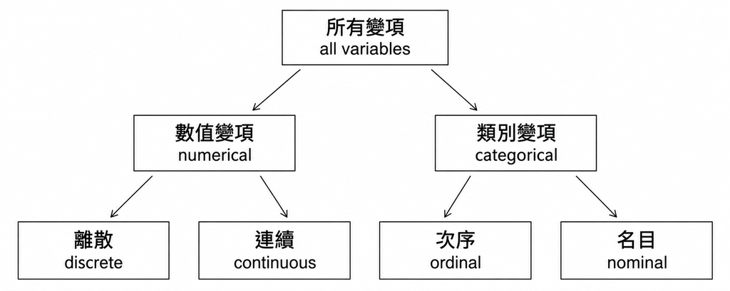

先判斷數值是否具有量的意義，再分辨取值方式或類別順序。

1.2.2 Types of variables · IMS Figure 1.1 · 中英標籤重製

## 這些數值，可以怎麼比較？

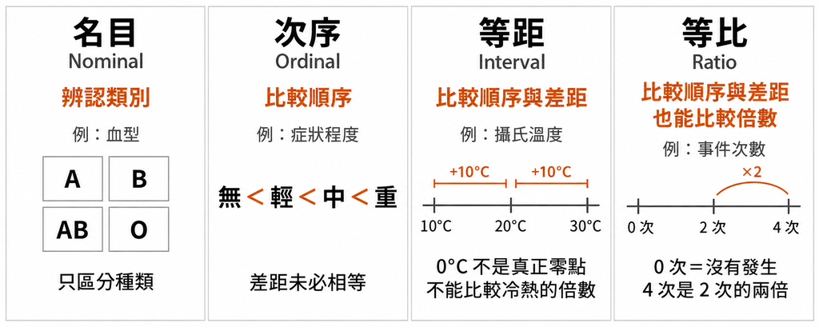

**離散／連續看取值方式；測量尺度（scale of measurement）看比較意義。**

事件次數：離散＋等比（ratio）；身高：連續＋等比。圖中另列等距（interval）尺度。

測量尺度 · [CDC：Types of Variables](https://archive.cdc.gov/www_cdc_gov/csels/dsepd/ss1978/lesson2/section2.html) · [ABS：Variables](https://www.abs.gov.au/statistics/understanding-statistics/statistical-terms-and-concepts/variables) · 自製比較圖

## 練習：看到數字，就能取平均？

| 紀錄 | 資料型態 |
| --- | --- |
| 身高 168.2 公分 | ？ |
| 三個月內偏頭痛 4 次 | ？ |
| 個人編號 1008 | ？ |
| 症狀程度：無、輕、中、重 | ？ |

依序為：連續數值、離散數值、識別欄位、次序類別。

1.2.2 Types of variables · 課堂練習

## 散布圖中的觀察單位與關聯

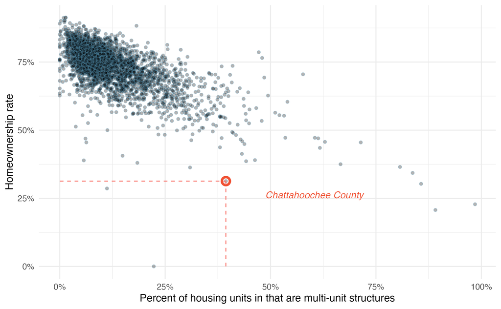

每個點代表一個郡；橫軸為多戶住宅比例，縱軸為住宅自有率。整體呈**負向關聯（negative association）**。

散布圖（scatterplot） 有關聯（associated） 負向關聯（negative association）

1.2.3 Relationships between variables · IMS Figure 1.2

## 正向關聯：收入與人口變化

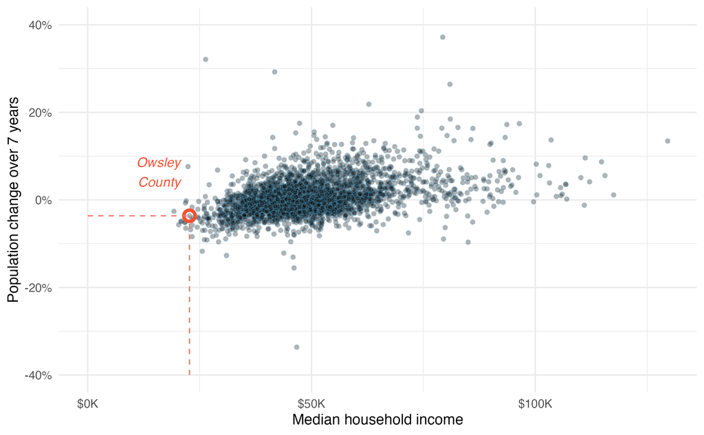

每個點是一個郡。收入較高時，人口變化通常如何？這是正向關聯（positive association），但表示每個郡都符合嗎？

1.2.3 Relationships between variables · IMS Figure 1.3

## 關聯（association）與獨立

| 概念 | 如何辨認？ |
| --- | --- |
| 正向關聯（positive association） | X 較高時，Y 通常也較高 |
| 負向關聯（negative association） | X 較高時，Y 通常較低 |
| 獨立（independent） | 兩個變項之間沒有相依關係 |

圖上沒有明顯趨勢，或相關係數（correlation coefficient）為零，都不足以證明獨立。

相依 dependent 關聯 association

1.2.3 Relationships between variables

## 解釋變項與結果變項

問題：郡的收入能否用來解釋或預測人口變化？

| 在問題中的角色 | 本例 |
| --- | --- |
| 解釋變項（explanatory variable） | 家戶所得中位數 |
| 結果變項（response variable） | 人口變化 |

解釋變項又稱為獨變項 (**independent variable**)

結果變項又稱為依變項 (**dependent variable**)

這些名稱描述分析角色；因果解釋（causal interpretation）仍須研究設計與其他依據。

1.2.4 Explanatory and response variables

## 實驗與觀察研究

### 實驗（experiment）

研究者分派處置。

若採隨機分派，稱為**隨機實驗（randomized experiment）**。

### 觀察研究（observational study）

記錄自然形成的處置或暴露差異。

可以追蹤一群符合條件的人，即**世代（cohort）**。

追蹤多久、是否在實驗室，都不足以單獨判定研究類型。

1.2.5 Observational studies and experiments

## 誰進入研究？誰接受哪種處置？

### 誰進入研究？

從誰之中選人？

哪些人實際提供資料？

### 誰接受哪種處置？

研究者如何決定組別？

還是記錄參與者自行選擇？

看到「隨機」一詞，要能辨別它發生在哪一步。

Ch. 2 Study design · 2.1 Sampling principles and strategies

## 母群體與樣本

| 概念 | 本例的對象 |
| --- | --- |
| 母群體（population） | 該校過去五年的全體畢業者 |
| 樣本（sample） | 實際取得資料的部分畢業者 |
| 普查（census） | 嘗試蒐集目標母群體中每個人的資料 |

尚未畢業的人，不屬於這個問題所界定的母群體。

2.1.1 Populations and samples

## 母群體參數與樣本統計量

### 想知道的量

全體畢業者的平均修業年數。

**母群體參數（population parameter）**

### 用手中資料算的量

樣本畢業者的平均修業年數。

**樣本統計量（sample statistic）**

用統計量估計參數時，仍有抽樣變異（sampling variability）與偏差（bias）需要考慮。

2.1.2 Parameters and statistics

## 軼事證據與便利樣本

| 蒐集方式 | 為何需要追問代表性？ |
| --- | --- |
| 記得兩位朋友都延後畢業 | 特殊案例可能特別容易被記住 |
| 只問身邊容易接觸的人 | 容易接觸者可能與其他人不同 |

個別經驗即使真實，也未必代表全體；還要看這些人是怎麼被選進研究的。

軼事證據（anecdotal evidence） 便利樣本（convenience sample） 具代表性（representative） 樣本偏差（sample bias）

2.1.3 Anecdotal evidence · 2.1.4 Sampling from a population